# pca_based_logistic_regression_sonar

## Fit a logistic regression model with PCA-based features

Compare the preprocessing steps and model fitting results to the elastic net model from last week. The PCA based features are used in logistic regression without a penalty, and logistic regression with the lasso (l1-norm) penalty. We will use the Sonar data set as last week.

After tuning both models, tree-based methods are quickly introduced to demonstrate models that do not require as much preprocessing steps.

```python
import numpy as np
import pandas as pd
import matplotlib.pyplot as plt

import seaborn as sns
```

## Load in Sonar data

```python
sonar_url = 'https://archive.ics.uci.edu/ml/machine-learning-databases/undocumented/connectionist-bench/sonar/sonar.all-data'

sonar_df = pd.read_csv( sonar_url, header=None, prefix='X' )
```

```python
print( sonar_df.shape )
```

```
(208, 61)
```

The last column is the binary outcome, the response we wish to classify.

```python
sonar_df.rename( columns={'X60': 'response'}, inplace=True)
```

```python
sonar_df.response = sonar_df.response.astype('category')
```

```python
sonar_df.head()
```

|  | X0 | X1 | X2 | X3 | X4 | X5 | X6 | X7 | X8 | X9 | ... | X51 | X52 | X53 | X54 | X55 | X56 | X57 | X58 | X59 | response |
| --- | --- | --- | --- | --- | --- | --- | --- | --- | --- | --- | --- | --- | --- | --- | --- | --- | --- | --- | --- | --- | --- |
| 0 | 0.0200 | 0.0371 | 0.0428 | 0.0207 | 0.0954 | 0.0986 | 0.1539 | 0.1601 | 0.3109 | 0.2111 | ... | 0.0027 | 0.0065 | 0.0159 | 0.0072 | 0.0167 | 0.0180 | 0.0084 | 0.0090 | 0.0032 | R |
| 1 | 0.0453 | 0.0523 | 0.0843 | 0.0689 | 0.1183 | 0.2583 | 0.2156 | 0.3481 | 0.3337 | 0.2872 | ... | 0.0084 | 0.0089 | 0.0048 | 0.0094 | 0.0191 | 0.0140 | 0.0049 | 0.0052 | 0.0044 | R |
| 2 | 0.0262 | 0.0582 | 0.1099 | 0.1083 | 0.0974 | 0.2280 | 0.2431 | 0.3771 | 0.5598 | 0.6194 | ... | 0.0232 | 0.0166 | 0.0095 | 0.0180 | 0.0244 | 0.0316 | 0.0164 | 0.0095 | 0.0078 | R |
| 3 | 0.0100 | 0.0171 | 0.0623 | 0.0205 | 0.0205 | 0.0368 | 0.1098 | 0.1276 | 0.0598 | 0.1264 | ... | 0.0121 | 0.0036 | 0.0150 | 0.0085 | 0.0073 | 0.0050 | 0.0044 | 0.0040 | 0.0117 | R |
| 4 | 0.0762 | 0.0666 | 0.0481 | 0.0394 | 0.0590 | 0.0649 | 0.1209 | 0.2467 | 0.3564 | 0.4459 | ... | 0.0031 | 0.0054 | 0.0105 | 0.0110 | 0.0015 | 0.0072 | 0.0048 | 0.0107 | 0.0094 | R |

5 rows × 61 columns

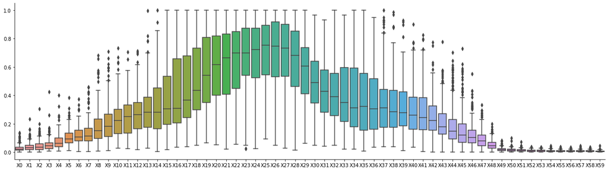

```python
sns.catplot(data = sonar_df, kind='box', aspect=3.5)

plt.show()
```

Look at the correlation plot between the features.

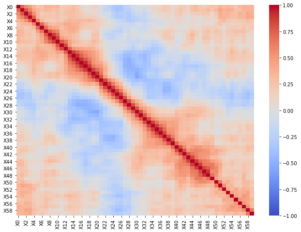

```python
fig, ax = plt.subplots(figsize=(11, 8))

sns.heatmap( data = sonar_df.corr(), vmin=-1, vmax=1, center=0, cmap='coolwarm')

plt.show()
```

## Import the modeling related modules

```python
from sklearn.preprocessing import StandardScaler
from sklearn.model_selection import RepeatedStratifiedKFold
from sklearn.linear_model import LogisticRegression

from sklearn.pipeline import Pipeline

from sklearn.model_selection import GridSearchCV

from sklearn.decomposition import PCA
```

## Separate the inputs from the response

```python
xinputs = sonar_df.select_dtypes('number').copy()
youtput = sonar_df.loc[:, ['response']].copy()
```

## Review PCA

Standardize the features. So let's use the entire data set for now.

```python
Xsonar = StandardScaler().fit_transform(xinputs)
```

```python
print( type(Xsonar) )
```

```
<class 'numpy.ndarray'>
```

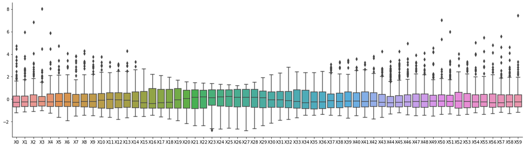

```python
sns.catplot(data = pd.DataFrame(Xsonar, columns=xinputs.columns), kind='box', aspect=3.5)

plt.show()
```

Perform PCA on the standardized set of features, and remember we are working with the **input** features for this problem. Use the "two line" approach where we first `.fit()` and then `.transform()`. Back when we worked on clustering, we would set the `n_components` argument equal to 2.

```python
pca_object_2 = PCA(n_components=2).fit(Xsonar)
```

But tonight, we will **not** set the `n_components` argument.

```python
pca_object = PCA().fit(Xsonar)
```

Apply PCA to the standardized features.

```python
sonar_pcs = pca_object.transform(Xsonar)
```

```python
print( type(sonar_pcs) )
```

```
<class 'numpy.ndarray'>
```

```python
print( sonar_pcs.shape )
```

```
(208, 60)
```

Check the shape of the input feature data set.

```python
print( Xsonar.shape )
```

```
(208, 60)
```

### What's going on with the PCs?

```python
'PC'+str(0+1).zfill(2)
```

```
'PC01'
```

```python
pc_names = ['PC'+str(d+1).zfill(2) for d in range(sonar_pcs.shape[1])]
```

Create a data frame of the transformed PC scores with the names stored in `pc_names`.

```python
sonar_pc_df = pd.DataFrame(sonar_pcs, columns=pc_names)
```

```python
sonar_pc_df.head()
```

|  | PC01 | PC02 | PC03 | PC04 | PC05 | PC06 | PC07 | PC08 | PC09 | PC10 | ... | PC51 | PC52 | PC53 | PC54 | PC55 | PC56 | PC57 | PC58 | PC59 | PC60 |
| --- | --- | --- | --- | --- | --- | --- | --- | --- | --- | --- | --- | --- | --- | --- | --- | --- | --- | --- | --- | --- | --- |
| 0 | 1.921168 | -1.370893 | -1.666476 | 0.837913 | -1.057324 | 1.712504 | 1.785716 | -1.581264 | 0.335418 | -1.028065 | ... | -0.335958 | -0.331626 | -0.198251 | -0.216336 | 0.097644 | -0.136728 | -0.004505 | -0.095476 | 0.037942 | 0.111545 |
| 1 | -0.480125 | 7.586388 | -1.275734 | 3.859346 | 2.121112 | -2.186818 | -1.742764 | 1.517061 | 0.307933 | -1.341882 | ... | -0.148443 | -0.072357 | -0.236929 | 0.284475 | -0.168813 | 0.392446 | -0.059563 | 0.284776 | 0.093821 | 0.066267 |
| 2 | 3.859228 | 6.439860 | -0.030635 | 5.454599 | 1.552060 | 1.181619 | -1.820138 | -1.495929 | -1.152459 | -1.006030 | ... | -0.217425 | 0.173613 | -0.244956 | 0.192608 | -0.243847 | -0.075688 | 0.234800 | -0.167007 | -0.064546 | 0.030407 |
| 3 | 4.597419 | -3.104089 | -1.785344 | -1.115908 | -2.785528 | -2.072673 | 2.084530 | 1.707289 | 0.452390 | -1.117318 | ... | -0.118437 | -0.143758 | -0.403720 | -0.138827 | 0.166721 | 0.169762 | 0.254800 | 0.036843 | -0.011256 | -0.081164 |
| 4 | -0.533868 | 1.849847 | -0.860097 | 3.302076 | 2.808954 | -0.783945 | 0.362657 | 0.812621 | 0.184578 | -0.023594 | ... | 0.231652 | 0.407619 | 0.218464 | 0.220151 | -0.106636 | 0.119250 | -0.153217 | 0.343264 | -0.092512 | -0.073373 |

5 rows × 60 columns

Let's look at the variation of the PCs and summarize with boxplots.

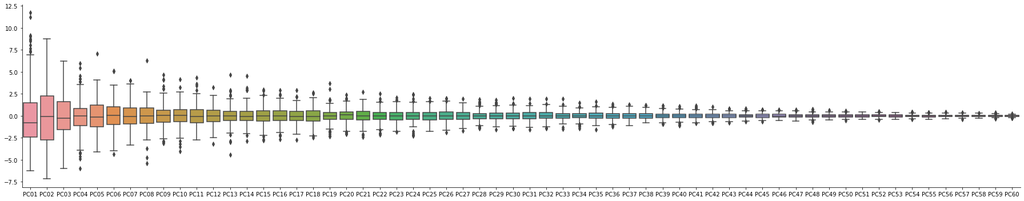

```python
sns.catplot(data = sonar_pc_df, kind='box', aspect=5)

plt.show()
```

The variation is getting smaller as we go from PC1 to PC60.

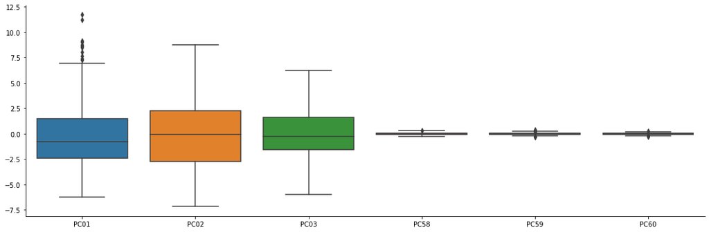

```python
sns.catplot(data = sonar_pc_df.loc[:, ['PC01', 'PC02', 'PC03', 'PC58', 'PC59', 'PC60']], kind='box', aspect=3)

plt.show()
```

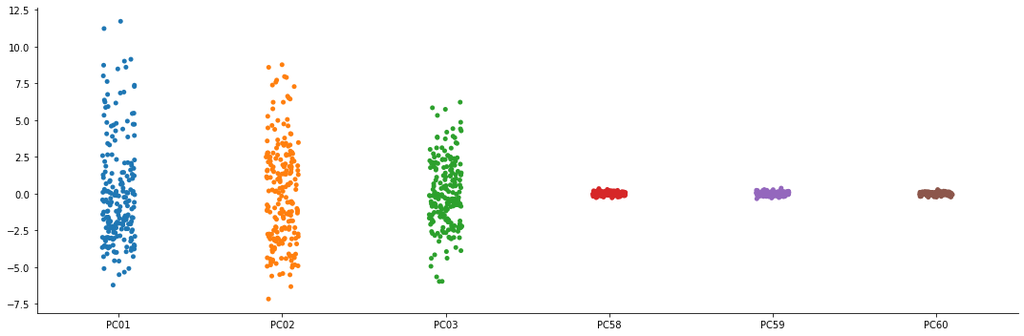

```python
sns.catplot(data = sonar_pc_df.loc[:, ['PC01', 'PC02', 'PC03', 'PC58', 'PC59', 'PC60']], aspect=3)

plt.show()
```

By construction, the FIRST Principal Component has the largest variance. The SECOND Principal Component (PC) has the second highest variance. The third PC the third highest variance, so on and so on.

Confirm by summarizing the standardization of the PCs and plotting. We will use the Pandas plotting options. Remember we can use `.describe()` method to quickly summarize variables in a data set.

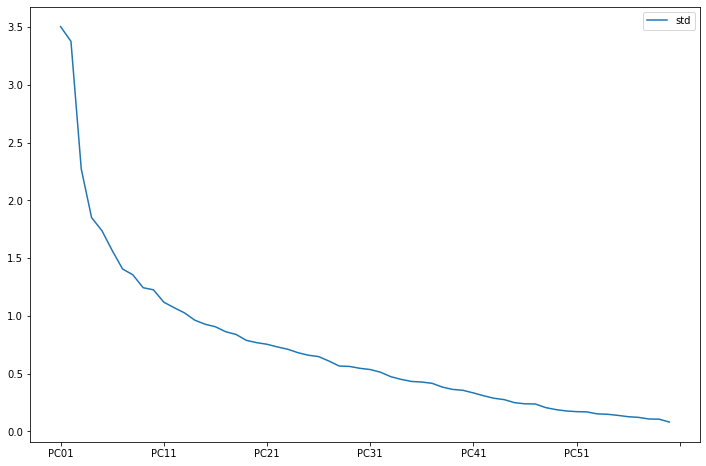

```python
fig, ax = plt.subplots(figsize=(12, 8))

sonar_pc_df.describe().T.loc[:, ['std']].plot(ax=ax)

plt.show()
```

The PCs are uncorrelated.

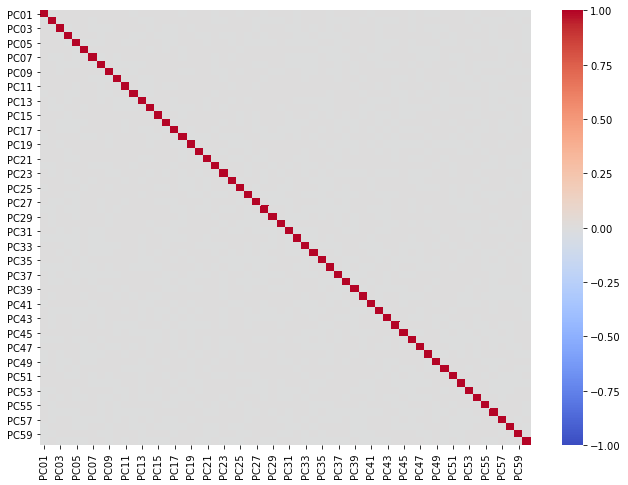

```python
fig, ax = plt.subplots(figsize=(11, 8))

sns.heatmap(data = sonar_pc_df.corr(), vmin=-1, vmax=1, center=0, cmap='coolwarm')

plt.show()
```

```python
sonar_pc_df.loc[:, ['PC01', 'PC02', 'PC03', 'PC58', 'PC59', 'PC60']].corr()
```

|  | PC01 | PC02 | PC03 | PC58 | PC59 | PC60 |
| --- | --- | --- | --- | --- | --- | --- |
| PC01 | 1.000000e+00 | -5.690983e-16 | 5.719569e-17 | -3.188481e-16 | -6.465539e-16 | -7.347605e-17 |
| PC02 | -5.690983e-16 | 1.000000e+00 | 5.794878e-17 | 1.397370e-15 | -6.383551e-16 | 6.196235e-16 |
| PC03 | 5.719569e-17 | 5.794878e-17 | 1.000000e+00 | 6.051206e-16 | 2.518507e-16 | -7.938339e-16 |
| PC58 | -3.188481e-16 | 1.397370e-15 | 6.051206e-16 | 1.000000e+00 | 1.041494e-16 | -1.363898e-15 |
| PC59 | -6.465539e-16 | -6.383551e-16 | 2.518507e-16 | 1.041494e-16 | 1.000000e+00 | 2.847316e-16 |
| PC60 | -7.347605e-17 | 6.196235e-16 | -7.938339e-16 | -1.363898e-15 | 2.847316e-16 | 1.000000e+00 |

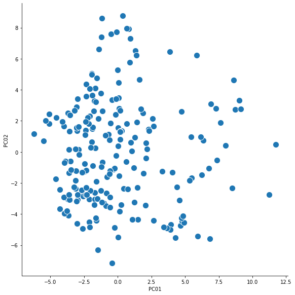

```python
sns.relplot(data = sonar_pc_df, x='PC01', y='PC02', s=150, height=8)

plt.show()
```

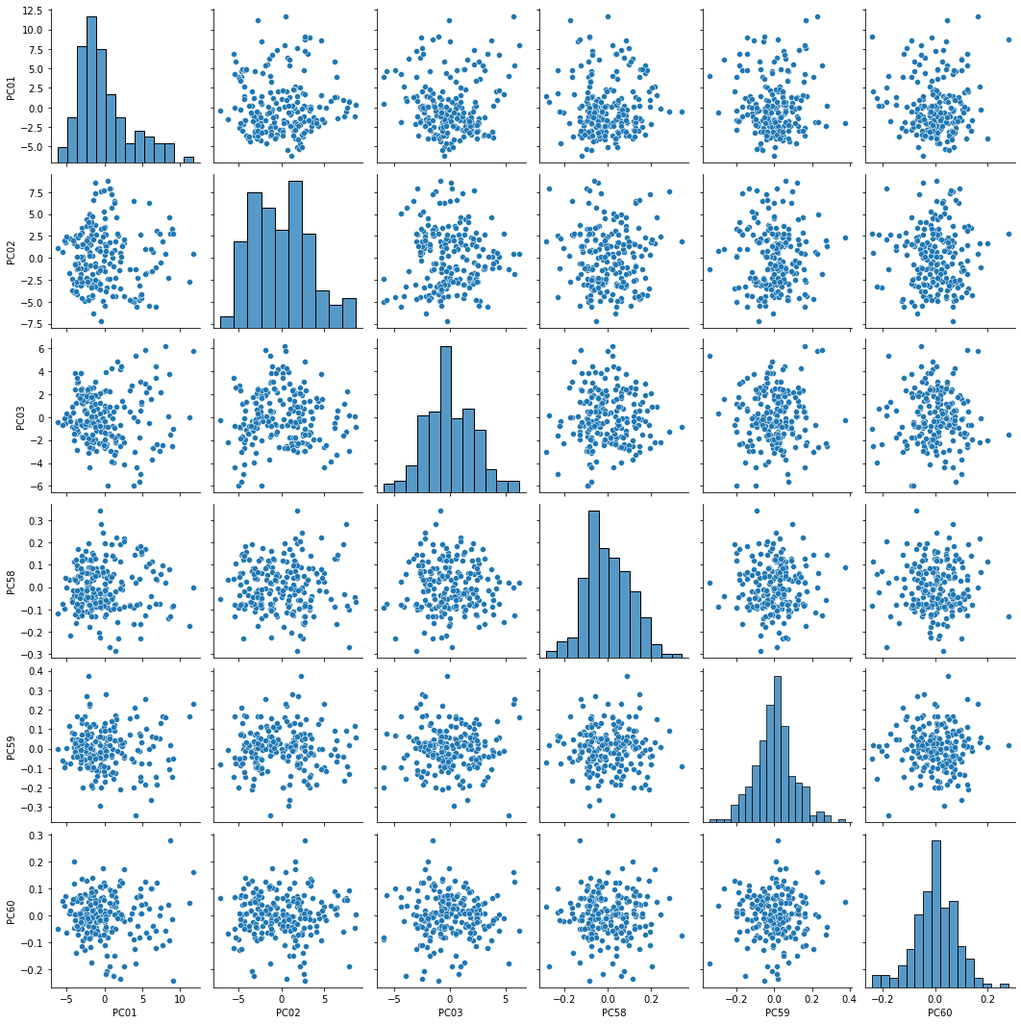

```python
sns.pairplot(data = sonar_pc_df, vars=['PC01', 'PC02', 'PC03', 'PC58', 'PC59', 'PC60'])

plt.show()
```

### How many PCs should we use?

The fraction of the variance explained for each PC.

```python
fraction_var_explain = pca_object.explained_variance_ratio_
```

```python
pc_numbers = np.arange(len(fraction_var_explain)) + 1
```

Create the "scree plot" to visualize the fraction of the variance explained for each PC.

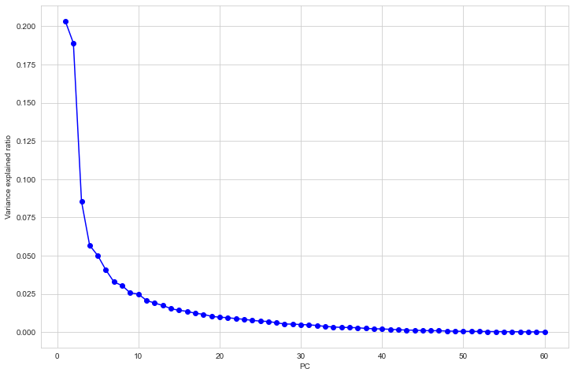

```python
sns.set_style('whitegrid')

fig, ax = plt.subplots(figsize=(12, 8))

ax.plot(pc_numbers, fraction_var_explain, 'bo-')

ax.set_xlabel('PC')
ax.set_ylabel('Variance explained ratio')

plt.show()
```

Another approach is to consider the cumulative variance explained, rather than the fraction per PC.

```python
total_var_explain = fraction_var_explain.cumsum()
```

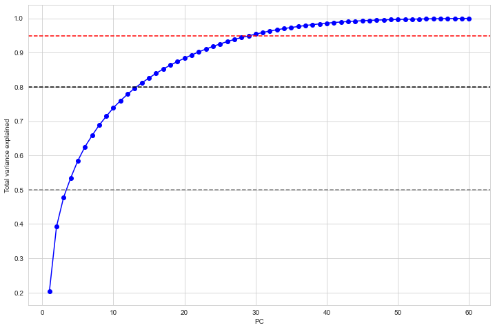

```python
fig, ax = plt.subplots(figsize=(12, 8))

ax.plot(pc_numbers, total_var_explain, 'bo-')

ax.axhline(y=0.5, color='grey', linestyle='--')

ax.axhline(y=0.8, color='black', linestyle='--')

ax.axhline(y=0.95, color = 'red', linestyle='--')

ax.set_xlabel('PC')
ax.set_ylabel('Total variance explained')

plt.show()
```

## PCA as a preprocessing step

PCA is sometimes referred as a feature extraction method when we have many correlated input features to a predictive model. We do not know how many PCs to retain. The approaches we discussed above are when we are **not** focused on predicting a response. When using PCA as a pre-processing step to extract features, we should **tune** the number of PCs with cross-validation.

We need to correctly executed within each cross-validation fold. We must first standardize, then perform PCA, extract the desired number of PCs, finally use those PCs as input features to a model. This is known as PC-regression (when predicting continuous responses), PC-based logistic regression (for binary responses). The PCs can even be used as input features to neural networks! This is known as neural networks with feature extraction.

We will use the Pipeline to appropriately apply the preprocessing steps before fitting the model.

### Create the pipeline

Use logistic regression without a penalty term. Initialize model objects.

```python
standardize_features = StandardScaler()

pca_to_fit = PCA()

logistic_mle = LogisticRegression(penalty='none', max_iter=10001, solver='lbfgs')
```

Define the pipeline.

```python
pca_logistic_workflow = Pipeline( steps= [ ('std_scale', standardize_features),
                                         ('pca', pca_to_fit),
                                         ('logistic', logistic_mle)])
```

We will tune the number of PCs to retain. Remember the Pipeline syntax requirements:

`<step>__<parameter>`

```python
### the tuning grid is a dictionary

pca_tune_grid = {'pca__n_components': [5, 10, 15, 20, 25, 30]}
```

### Define the cross-validation

```python
my_cv = RepeatedStratifiedKFold(n_splits=5, n_repeats=3, random_state=101)
```

### Define the NumPy feature arrays

```python
X_train = xinputs.to_numpy()

y_train = youtput.response.to_numpy().ravel()
```

```python
print( y_train.shape )
```

```
(208,)
```

### Perform the grid-search cross-validation

```python
pca_logistic_search = GridSearchCV(pca_logistic_workflow, pca_tune_grid, cv=my_cv)
```

Execute the grid-search.

```python
pca_logistic_search_results = pca_logistic_search.fit(X_train, y_train)
```

### Grid-search results

```python
pca_logistic_search_results.best_params_
```

```
{'pca__n_components': 20}
```

```python
pca_logistic_search_results.best_score_
```

```
0.7868370112272551
```

Check the coefficients of the best model.

```python
pca_logistic_search_results.best_estimator_.named_steps
```

```
{'std_scale': StandardScaler(),
 'pca': PCA(n_components=20),
 'logistic': LogisticRegression(max_iter=10001, penalty='none')}
```

```python
pca_logistic_search_results.best_estimator_.named_steps['logistic'].coef_
```

```
array([[-0.35707938, -0.36503551, -1.29849518,  0.07921078,  0.13316245,
        -0.10268694, -0.57927919, -0.05157235,  1.11871677, -0.74668348,
        -0.07595357,  0.06017968, -0.13318428, -0.74700353,  0.21274968,
        -0.07199487, -0.74558299, -0.19764689, -0.66404369,  0.37063259]])
```

## Use the PCs as input features for Lasso

Can we "turn-off" less important PCs, even if we need to retain a large number.

```python
lasso_mod = LogisticRegression(penalty='l1', solver='saga', random_state=101, max_iter=10001)
```

We need to define a new workflow.

```python
pca_lasso_workflow = Pipeline( steps=[ ('std_scale', standardize_features),
                                      ('pca', pca_to_fit),
                                      ('lasso', lasso_mod) ])
```

Define the grid of tuning parameters. We have 2 tuning parameters now. The number of PCs to retain and the value for the penalty, the `C` parameter in the logistic regression model with the `l1` penalty.

```python
np.linspace(-6, 6, 25)
```

```
array([-6. , -5.5, -5. , -4.5, -4. , -3.5, -3. , -2.5, -2. , -1.5, -1. ,
       -0.5,  0. ,  0.5,  1. ,  1.5,  2. ,  2.5,  3. ,  3.5,  4. ,  4.5,
        5. ,  5.5,  6. ])
```

```python
np.exp( np.linspace(-6, 6, 25) )
```

```
array([2.47875218e-03, 4.08677144e-03, 6.73794700e-03, 1.11089965e-02,
       1.83156389e-02, 3.01973834e-02, 4.97870684e-02, 8.20849986e-02,
       1.35335283e-01, 2.23130160e-01, 3.67879441e-01, 6.06530660e-01,
       1.00000000e+00, 1.64872127e+00, 2.71828183e+00, 4.48168907e+00,
       7.38905610e+00, 1.21824940e+01, 2.00855369e+01, 3.31154520e+01,
       5.45981500e+01, 9.00171313e+01, 1.48413159e+02, 2.44691932e+02,
       4.03428793e+02])
```

```python
pca_lasso_grid = {'pca__n_components': [10, 20, 30], 'lasso__C': np.exp(np.linspace(-6, 6, 25))}
```

```python
5 * 3 * 3 * 25
```

```
1125
```

```python
pca_lasso_search = GridSearchCV(pca_lasso_workflow, pca_lasso_grid, cv=my_cv)
```

Execute the grid search.

```python
pca_lasso_search_results = pca_lasso_search.fit(X_train, y_train)
```

Look at the results.

```python
pca_lasso_search_results.best_params_
```

```
{'lasso__C': 0.36787944117144233, 'pca__n_components': 20}
```

```python
pca_lasso_search_results.best_score_
```

```
0.7998064266356949
```

Examine the coefficients.

```python
pca_lasso_search_results.best_estimator_.named_steps['lasso'].coef_
```

```
array([[-0.2460096 , -0.27235448, -0.8950389 ,  0.        ,  0.06781045,
        -0.04649455, -0.38975956,  0.        ,  0.73341947, -0.46306327,
         0.        ,  0.        ,  0.        , -0.41377524,  0.        ,
         0.        , -0.37870554,  0.        , -0.15630458,  0.0446013 ]])
```

## Tree-based methods

We will not get into the details of the tree based methods, but it can be useful to see how the (generalized) linear approaches that we have used compare to non-linear methods.

https://scikit-learn.org/stable/modules/tree.html

### The basic Decision Tree - CART

```python
from sklearn.tree import DecisionTreeClassifier
```

We will assess the performance of a decision tree using `cross_val_score()`.

```python
from sklearn.model_selection import cross_val_score
```

Initialize the model object using all default settings.

```python
my_cart = DecisionTreeClassifier()
```

Use the 5-fold with 3-repeats cross-validation to assess the accuracy of the decision tree.

```python
cart_cv_results = cross_val_score(my_cart, X_train, y_train, cv=my_cv, scoring='accuracy')
```

```python
cart_cv_results
```

```
array([0.78571429, 0.78571429, 0.73809524, 0.82926829, 0.7804878 ,
       0.73809524, 0.64285714, 0.71428571, 0.70731707, 0.65853659,
       0.78571429, 0.61904762, 0.69047619, 0.85365854, 0.65853659])
```

The average performance of the basic decision tree is the average of the above values.

```python
cart_cv_results.mean()
```

```
0.7325203252032519
```

### Fit one tree

```python
one_tree = DecisionTreeClassifier().fit(X_train, y_train)
```

Visualize and interpret a decision tree.

```python
from sklearn.tree import plot_tree
```

```python
#plot_tree(one_tree)
```

In lecture, the arrow between the decisions were not displayed. This is an unfortunate issue due to using Seaborn with the sklearn `plot_tree()` function. The arrows are displayed with a "hack" below by setting the background color to black which makes the white arrows visible. If we had not called `sns.set_style()` earlier, the figure below would not need the `facecolor` changed.

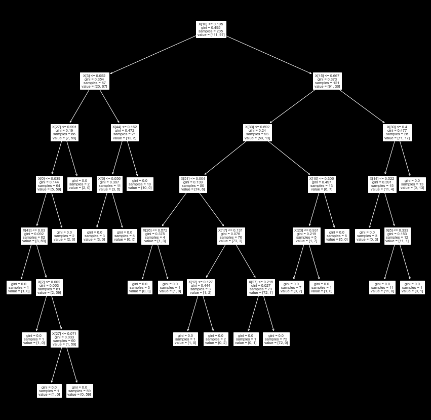

```python
fig, ax = plt.subplots(figsize=(15, 15), facecolor='k')

viz_cart = plot_tree(one_tree, ax=ax)
```

## Ensemble of trees

Fit hundreds of decision trees to slight variations of the training set. Average across those trees. This known as the bagged tree. And if we randomly select the number of features to consider when making a split in the tree, that's known as the **random forest**.

https://scikit-learn.org/stable/modules/generated/sklearn.ensemble.RandomForestClassifier.html

https://scikit-learn.org/stable/modules/generated/sklearn.ensemble.RandomForestRegressor.html

```python
from sklearn.ensemble import RandomForestClassifier
```

Initialize our random forest. We will use 500 trees, so all predictions will average over 500 different models.

```python
my_rf = RandomForestClassifier(n_estimators=500, max_features='auto', random_state=412)
```

Use `cross_val_score()` to assess the performance of the random forest.

```python
rf_cv_results = cross_val_score(my_rf, X_train, y_train, cv=my_cv, scoring='accuracy')
```

```python
rf_cv_results.mean()
```

```
0.851025938830817
```

```python
rf_cv_results
```

```
array([0.85714286, 0.88095238, 0.76190476, 0.85365854, 0.87804878,
       0.80952381, 0.92857143, 0.73809524, 0.95121951, 0.87804878,
       0.85714286, 0.88095238, 0.9047619 , 0.7804878 , 0.80487805])
```

```python
rf_cv_results.std()
```

```
0.058763160288222406
```

```python
rf_cv_results.std() / np.sqrt( len(rf_cv_results) )
```

```
0.015172582744453494
```

### Variable importance

```python
my_rf_fit = my_rf.fit(X_train, y_train)
```

```python
my_rf_fit.n_estimators
```

```
500
```

```python
my_rf_fit.max_features
```

```
'auto'
```

```python
my_rf_fit.feature_importances_
```

```
array([0.01394126, 0.00968322, 0.0079458 , 0.01990523, 0.0189219 ,
       0.01116323, 0.00862521, 0.01165608, 0.04808965, 0.04160489,
       0.05642401, 0.05576734, 0.0320151 , 0.00944931, 0.01419811,
       0.01667386, 0.01645249, 0.01596988, 0.01057475, 0.01522268,
       0.02309929, 0.01153753, 0.0142884 , 0.00801939, 0.00747593,
       0.01003775, 0.01896704, 0.01947593, 0.00956701, 0.01056709,
       0.01541418, 0.01125153, 0.01053136, 0.00928182, 0.01154331,
       0.02431066, 0.01743422, 0.00880092, 0.0140668 , 0.01058031,
       0.00848122, 0.01200842, 0.012251  , 0.01605935, 0.0219122 ,
       0.0199622 , 0.0209891 , 0.02804098, 0.03512966, 0.00779367,
       0.02477156, 0.02014122, 0.00728076, 0.01181972, 0.0112363 ,
       0.00653157, 0.00819034, 0.00943044, 0.00935046, 0.00808536])
```

```python
var_imp_df = pd.DataFrame({'feature_name': xinputs.columns,
                          'var_imp': my_rf_fit.feature_importances_})
```

```python
var_imp_df
```

|  | feature_name | var_imp |
| --- | --- | --- |
| 0 | X0 | 0.013941 |
| 1 | X1 | 0.009683 |
| 2 | X2 | 0.007946 |
| 3 | X3 | 0.019905 |
| 4 | X4 | 0.018922 |
| 5 | X5 | 0.011163 |
| 6 | X6 | 0.008625 |
| 7 | X7 | 0.011656 |
| 8 | X8 | 0.048090 |
| 9 | X9 | 0.041605 |
| 10 | X10 | 0.056424 |
| 11 | X11 | 0.055767 |
| 12 | X12 | 0.032015 |
| 13 | X13 | 0.009449 |
| 14 | X14 | 0.014198 |
| 15 | X15 | 0.016674 |
| 16 | X16 | 0.016452 |
| 17 | X17 | 0.015970 |
| 18 | X18 | 0.010575 |
| 19 | X19 | 0.015223 |
| 20 | X20 | 0.023099 |
| 21 | X21 | 0.011538 |
| 22 | X22 | 0.014288 |
| 23 | X23 | 0.008019 |
| 24 | X24 | 0.007476 |
| 25 | X25 | 0.010038 |
| 26 | X26 | 0.018967 |
| 27 | X27 | 0.019476 |
| 28 | X28 | 0.009567 |
| 29 | X29 | 0.010567 |
| 30 | X30 | 0.015414 |
| 31 | X31 | 0.011252 |
| 32 | X32 | 0.010531 |
| 33 | X33 | 0.009282 |
| 34 | X34 | 0.011543 |
| 35 | X35 | 0.024311 |
| 36 | X36 | 0.017434 |
| 37 | X37 | 0.008801 |
| 38 | X38 | 0.014067 |
| 39 | X39 | 0.010580 |
| 40 | X40 | 0.008481 |
| 41 | X41 | 0.012008 |
| 42 | X42 | 0.012251 |
| 43 | X43 | 0.016059 |
| 44 | X44 | 0.021912 |
| 45 | X45 | 0.019962 |
| 46 | X46 | 0.020989 |
| 47 | X47 | 0.028041 |
| 48 | X48 | 0.035130 |
| 49 | X49 | 0.007794 |
| 50 | X50 | 0.024772 |
| 51 | X51 | 0.020141 |
| 52 | X52 | 0.007281 |
| 53 | X53 | 0.011820 |
| 54 | X54 | 0.011236 |
| 55 | X55 | 0.006532 |
| 56 | X56 | 0.008190 |
| 57 | X57 | 0.009430 |
| 58 | X58 | 0.009350 |
| 59 | X59 | 0.008085 |

Let's visualize the importances with a stem plot.

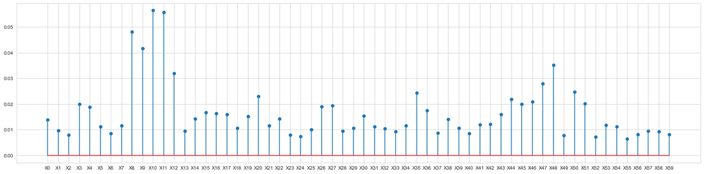

```python
fig, ax = plt.subplots(figsize=(25, 6))

ax.stem(var_imp_df.feature_name, var_imp_df.var_imp)

plt.show()
```

Sort the variable importances in descending order.

```python
sort_var_imp_df = var_imp_df.sort_values(by=['var_imp'], ascending=False).copy()
```

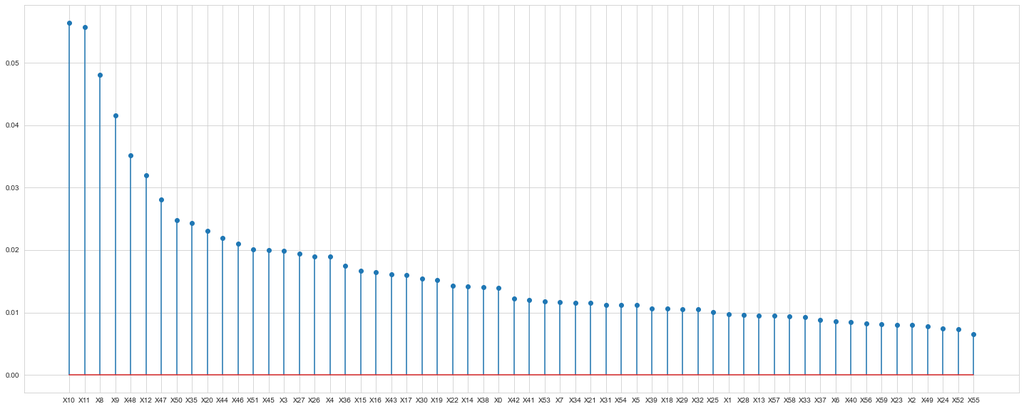

```python
fig, ax = plt.subplots(figsize=(25, 10))

ax.stem(sort_var_imp_df.feature_name, sort_var_imp_df.var_imp)

plt.show()
```